# PGA Tour Data Analysis

Connor Paszkiewicz, Jack Campanella

2023-12-11

### Load Necessary Libraries

```r
library(lubridate)
library(gifski)
library(png)
library(tidyverse)
```

```r
library(ggplot2)
library(ggdark)
library(gganimate)
library(reshape2)
library(ggridges)
```

### Load & View the Data

```r
pga_df <- read_csv("./PGA Tour Raw Data.csv")
pga_season_df <- read_csv("./PGA Season Data.csv")
dim(pga_df)
```

```
## [1] 36864    37
```

```r
dim(pga_season_df)
```

```
## [1] 3834   18
```

```r
head(pga_df)
```

```
## # A tibble: 6 × 37
##   Player_initial_last `tournament id` `player id` hole_par strokes hole_DKP
##   <chr>                         <dbl>       <dbl>    <dbl>   <dbl>    <dbl>
## 1 A. Ancer                  401353224        9261      288     289     60
## 2 A. Hadwin                 401353224        5548      288     286     72.5
## 3 A. Lahiri                 401353224        4989      144     147     21.5
## 4 A. Long                   401353224        6015      144     151     20.5
## 5 A. Noren                  401353224        3832      144     148     23.5
## 6 A. Putnam                 401353224        5502      144     151     19.5
## # ℹ 31 more variables: hole_FDP <dbl>, hole_SDP <dbl>, streak_DKP <dbl>,
## #   streak_FDP <dbl>, streak_SDP <dbl>, n_rounds <dbl>, made_cut <dbl>,
## #   pos <dbl>, finish_DKP <dbl>, finish_FDP <dbl>, finish_SDP <dbl>,
## #   total_DKP <dbl>, total_FDP <dbl>, total_SDP <dbl>, player <chr>,
## #   `Unnamed: 2` <lgl>, `Unnamed: 3` <lgl>, `Unnamed: 4` <lgl>,
## #   `tournament name` <chr>, course <chr>, date <chr>, purse <dbl>,
## #   season <dbl>, no_cut <dbl>, Finish <chr>, sg_putt <dbl>, sg_arg <dbl>, …
```

```r
head(pga_season_df)
```

```
## # A tibble: 6 × 18
##      RK Name      AGE   EARNINGS   CUP EVNTS  RNDS  CUTS TOP10  WINS SCORE  DDIS
##   <dbl> <chr>     <chr> <chr>    <dbl> <dbl> <dbl> <dbl> <dbl> <dbl> <dbl> <dbl>
## 1     1 Tiger Wo… 47    $8,553,…  2742    16    60    16     8     5  69.9  293.
## 2     2 Henrik S… 47    $6,388,…  4750    18    64    16     8     2  69.9  291.
## 3     3 Matt Kuc… 45    $5,616,…  1823    23    87    23     8     2  70    285.
## 4     4 Phil Mic… 53    $5,495,…  1313    21    78    18     7     2  70.1  288.
## 5     5 Brandt S… 42    $5,318,…   852    23    79    17     9     2  70.2  281.
## 6     6 Adam Sco… 43    $4,892,…  2277    16    60    16     6     2  70.3  298.
## # ℹ 6 more variables: DACC <dbl>, GIR <dbl>, PUTTS <dbl>, SAND <dbl>,
## #   BIRDS <dbl>, season <dbl>
```

### Make sure both tables are properly loaded for analysis

```r
sapply(pga_df, class)
```

```
## Player_initial_last       tournament id           player id            hole_par
##         "character"           "numeric"           "numeric"           "numeric"
##             strokes            hole_DKP            hole_FDP            hole_SDP
##           "numeric"           "numeric"           "numeric"           "numeric"
##          streak_DKP          streak_FDP          streak_SDP            n_rounds
##           "numeric"           "numeric"           "numeric"           "numeric"
##            made_cut                 pos          finish_DKP          finish_FDP
##           "numeric"           "numeric"           "numeric"           "numeric"
##          finish_SDP           total_DKP           total_FDP           total_SDP
##           "numeric"           "numeric"           "numeric"           "numeric"
##              player          Unnamed: 2          Unnamed: 3          Unnamed: 4
##         "character"           "logical"           "logical"           "logical"
##     tournament name              course                date               purse
##         "character"         "character"         "character"           "numeric"
##              season              no_cut              Finish             sg_putt
##           "numeric"           "numeric"         "character"           "numeric"
##              sg_arg              sg_app              sg_ott              sg_t2g
##           "numeric"           "numeric"           "numeric"           "numeric"
##            sg_total
##           "numeric"
```

```r
sapply(pga_season_df, class)
```

```
##          RK        Name         AGE    EARNINGS         CUP       EVNTS
##   "numeric" "character" "character" "character"   "numeric"   "numeric"
##        RNDS        CUTS       TOP10        WINS       SCORE        DDIS
##   "numeric"   "numeric"   "numeric"   "numeric"   "numeric"   "numeric"
##        DACC         GIR       PUTTS        SAND       BIRDS      season
##   "numeric"   "numeric"   "numeric"   "numeric"   "numeric"   "numeric"
```

```r
summary(pga_season_df$AGE)
```

```
##    Length     Class      Mode
##      3834 character character
```

We want to convert the AGE column to the numeric data type and also calculate a player’s age during a specific season using their current age

```r
pga_season_df$AGE <- sapply(pga_season_df$AGE, as.numeric)
```

[output not shown]

[output cut: 298 more lines]

[output not shown]

```r
pga_season_df$true_age <- pga_season_df$AGE - (year(Sys.Date()) - pga_season_df$season)
```

Before we can join any data, we have to match the naming conventions across the two tables so that we can join based on name. This assumes that no two players have the same First Initial Last Name (e.g. T. Woods) and therefore name serves as a unique key.

```r
# Extracting first initial
first_initial <- substr(pga_season_df$Name, 1, 1)

# Extracting last name
last_name <- sub("^.*\\s", "", pga_season_df$Name)

# Combine First Initial and Last Name
pga_season_df$Player_initial_last <- paste(first_initial, '. ', last_name, sep = '')

head(pga_season_df)
```

```
## # A tibble: 6 × 20
##      RK Name        AGE EARNINGS   CUP EVNTS  RNDS  CUTS TOP10  WINS SCORE  DDIS
##   <dbl> <chr>     <dbl> <chr>    <dbl> <dbl> <dbl> <dbl> <dbl> <dbl> <dbl> <dbl>
## 1     1 Tiger Wo…    47 $8,553,…  2742    16    60    16     8     5  69.9  293.
## 2     2 Henrik S…    47 $6,388,…  4750    18    64    16     8     2  69.9  291.
## 3     3 Matt Kuc…    45 $5,616,…  1823    23    87    23     8     2  70    285.
## 4     4 Phil Mic…    53 $5,495,…  1313    21    78    18     7     2  70.1  288.
## 5     5 Brandt S…    42 $5,318,…   852    23    79    17     9     2  70.2  281.
## 6     6 Adam Sco…    43 $4,892,…  2277    16    60    16     6     2  70.3  298.
## # ℹ 8 more variables: DACC <dbl>, GIR <dbl>, PUTTS <dbl>, SAND <dbl>,
## #   BIRDS <dbl>, season <dbl>, true_age <dbl>, Player_initial_last <chr>
```

We also want to create a table that only contains unique players and their current ages.

```r
age_df <- pga_season_df[c('Player_initial_last', 'season', 'true_age')]
head(age_df)
```

```
## # A tibble: 6 × 3
##   Player_initial_last season true_age
##   <chr>                <dbl>    <dbl>
## 1 T. Woods              2013       37
## 2 H. Stenson            2013       37
## 3 M. Kuchar             2013       35
## 4 P. Mickelson          2013       43
## 5 B. Snedeker           2013       32
## 6 A. Scott              2013       33
```

Get unique players and their current ages.

```r
age_df <- distinct(age_df, Player_initial_last, .keep_all = TRUE)
dim(age_df)
```

```
## [1] 810   3
```

```r
head(age_df)
```

```
## # A tibble: 6 × 3
##   Player_initial_last season true_age
##   <chr>                <dbl>    <dbl>
## 1 T. Woods              2013       37
## 2 H. Stenson            2013       37
## 3 M. Kuchar             2013       35
## 4 P. Mickelson          2013       43
## 5 B. Snedeker           2013       32
## 6 A. Scott              2013       33
```

That leaves us with 810 unique player names and their ages.

### Merge the Two Tables

Having done all the prep work, we can now join the two tables.

We will then need to look at if age is null for players and deal with that accordingly.

```r
pga_df <- merge(pga_df,
                pga_season_df,
                by = c('Player_initial_last', 'season'),
                all.x = TRUE)
```

```r
dim(pga_df)
```

```
## [1] 37923    55
```

```r
head(pga_df)
```

```
##   Player_initial_last season tournament id player id hole_par strokes hole_DKP
## 1        A. Albertson   2017          2729     10357      142     136     40.5
## 2        A. Albertson   2019     401056503     10357      288     274     83.5
## 3        A. Albertson   2019     401056525     10357      144     147     21.5
## 4        A. Albertson   2019     401056506     10357      282     269     80.5
## 5        A. Albertson   2019     401056555     10357      140     146     24.5
## 6        A. Albertson   2019     401056550     10357      142     145     30.0
##   hole_FDP hole_SDP streak_DKP streak_FDP streak_SDP n_rounds made_cut pos
## 1     39.1       37          3       12.6          3        2        0  74
## 2     80.7       79          6       24.4          7        4        1   5
## 3     17.4       27          0        0.2          0        2        0  NA
## 4     77.2       81          3       16.8          4        4        1  15
## 5     17.2       20          3        6.4          3        2        0  NA
## 6     23.1       24          0        0.6          0        2        0  NA
##   finish_DKP finish_FDP finish_SDP total_DKP total_FDP total_SDP
```

[output cut: 48 more lines]

### Data Cleaning

```r
# drop null columns and the extra name column
pga_df <- subset(pga_df, select = -c(`Unnamed: 2`, `Unnamed: 3`, `Unnamed: 4`))
dim(pga_df)
```

```
## [1] 37923    52
```

```r
# remove rows where shots gained variables are null
pga_df <- pga_df[complete.cases(pga_df[ , 29:34]),]
dim(pga_df)
```

```
## [1] 29882    52
```

```r
summary(pga_df)
```

```
##  Player_initial_last     season     tournament id         player id
##  Length:29882        Min.   :2015   Min.   :     2232   Min.   :      5
##  Class :character    1st Qu.:2017   1st Qu.:     2708   1st Qu.:   1185
##  Mode  :character    Median :2019   Median :401056520   Median :   3856
##                      Mean   :2019   Mean   :251848294   Mean   :  78282
##                      3rd Qu.:2021   3rd Qu.:401223849   3rd Qu.:   6629
##                      Max.   :2022   Max.   :401353273   Max.   :4845309
##
##     hole_par        strokes         hole_DKP         hole_FDP
##  Min.   : 70.0   Min.   : 66.0   Min.   : -2.50   Min.   :-21.40
##  1st Qu.:142.0   1st Qu.:146.0   1st Qu.: 26.50   1st Qu.: 22.10
##  Median :280.0   Median :270.0   Median : 51.50   Median : 43.80
##  Mean   :222.1   Mean   :220.8   Mean   : 49.29   Mean   : 43.59
##  3rd Qu.:284.0   3rd Qu.:280.0   3rd Qu.: 69.00   3rd Qu.: 63.50
##  Max.   :292.0   Max.   :313.0   Max.   :174.00   Max.   :134.70
##
##     hole_SDP        streak_DKP       streak_FDP       streak_SDP
##  Min.   :-11.00   Min.   : 0.000   Min.   : 0.000   Min.   : 0.000
##  1st Qu.: 27.00   1st Qu.: 0.000   1st Qu.: 0.800   1st Qu.: 0.000
##  Median : 53.00   Median : 0.000   Median : 6.400   Median : 0.000
##  Mean   : 48.49   Mean   : 1.716   Mean   : 7.509   Mean   : 1.624
##  3rd Qu.: 68.00   3rd Qu.: 3.000   3rd Qu.:12.200   3rd Qu.: 3.000
##  Max.   :107.00   Max.   :23.000   Max.   :43.600   Max.   :22.000
##
##     n_rounds        made_cut           pos           finish_DKP
##  Min.   :1.000   Min.   :0.0000   Min.   :  1.00   Min.   : 0.000
##  1st Qu.:2.000   1st Qu.:0.0000   1st Qu.: 16.00   1st Qu.: 0.000
##  Median :4.000   Median :1.0000   Median : 33.00   Median : 0.000
##  Mean   :3.124   Mean   :0.5799   Mean   : 34.56   Mean   : 2.325
##  3rd Qu.:4.000   3rd Qu.:1.0000   3rd Qu.: 52.00   3rd Qu.: 3.000
##  Max.   :4.000   Max.   :1.0000   Max.   :999.00   Max.   :30.000
##                                   NA's   :13384
##    finish_FDP       finish_SDP       total_DKP        total_FDP
##  Min.   : 0.000   Min.   : 0.000   Min.   : -2.50   Min.   :-21.40
##  1st Qu.: 0.000   1st Qu.: 0.000   1st Qu.: 27.00   1st Qu.: 24.10
##  Median : 0.000   Median : 0.000   Median : 53.50   Median : 49.30
##  Mean   : 1.988   Mean   : 1.088   Mean   : 53.33   Mean   : 53.09
##  3rd Qu.: 2.000   3rd Qu.: 0.000   3rd Qu.: 74.50   3rd Qu.: 77.60
##  Max.   :30.000   Max.   :15.000   Max.   :205.50   Max.   :202.60
##
```

[output cut: 49 more lines]

```
##  Min.   : 0.00   Min.   :  0.0   Min.   : 0.00   Min.   : 0.00
##  1st Qu.:70.10   1st Qu.:280.9   1st Qu.:52.50   1st Qu.:62.00
##  Median :70.50   Median :292.5   Median :59.40   Median :65.50
##  Mean   :67.15   Mean   :234.2   Mean   :48.43   Mean   :52.43
##  3rd Qu.:70.90   3rd Qu.:299.8   3rd Qu.:63.80   3rd Qu.:67.60
##  Max.   :75.30   Max.   :323.7   Max.   :76.90   Max.   :74.20
##  NA's   :2308    NA's   :2308    NA's   :2308    NA's   :2308
##      PUTTS            SAND           BIRDS          true_age
##  Min.   :0.000   Min.   : 0.00   Min.   :0.000   Min.   :20.00
##  1st Qu.:1.726   1st Qu.:40.50   1st Qu.:3.413   1st Qu.:29.00
##  Median :1.757   Median :48.40   Median :3.634   Median :33.00
##  Mean   :1.397   Mean   :39.78   Mean   :3.371   Mean   :33.76
##  3rd Qu.:1.777   3rd Qu.:52.90   3rd Qu.:3.826   3rd Qu.:38.00
##  Max.   :1.856   Max.   :68.70   Max.   :5.250   Max.   :63.00
##  NA's   :2308    NA's   :2308    NA's   :2308    NA's   :2610
```

There are 2610 null age values. Let’s see which players these belong to.

```r
length(unique(pga_df[is.na(pga_df$AGE),]$Player_initial_last))
```

```
## [1] 299
```

```r
length(unique(pga_df[!is.na(pga_df$AGE),]$Player_initial_last))
```

```
## [1] 354
```

```r
unique(pga_df[is.na(pga_df$AGE),]$Player_initial_last)
```

```
##   [1] "A. Beach"           "A. Bhatia"          "A. Bjork"
##   [4] "A. Cejka"           "A. Cook"            "A. Eckroat"
##   [7] "A. Flanagan"        "A. Gonzales"        "A. Landry"
##  [10] "A. Levy"            "A. Loupe"           "A. Ogletree"
##  [13] "A. Ortiz"           "A. Rai"             "A. Rozner"
##  [16] "A. Smalley"         "A. Sullivan"        "A. Svensson"
##  [19] "A. Truslow"         "B. Barber"          "B. Cook"
##  [22] "B. Crane"           "B. Davis"           "B. de Jonge"
##  [25] "B. DeChambeau"      "B. Dwyer"           "B. Garnett"
##  [28] "B. Grace"           "B. Harkins"         "B. Hebert"
##  [31] "B. Kennedy"         "B. Langer"          "B. Marek"
##  [34] "B. Martin"          "B. Nimmer"          "B. Paolini"
##  [37] "B. Polland"         "B. Schnell"         "B. Silverman"
##  [40] "B. Stone"           "B. Todd"            "B. Van Pelt"
##  [43] "B. Wiesberger"      "B. Wu"              "C. Baker"
```

[output cut: 85 more lines]

These 299 unique players only make up 2610 rows in the dataset, whereas the 354 players with age values make up the other 27,272 rows in the data set. Therefore, we will drop the players with null ages for analyses dealing with age.

```r
pga_df_valid_age <- pga_df[!is.na(pga_df$AGE),]
dim(pga_df_valid_age)
```

```
## [1] 27272    52
```

# Data Exploration

## Shots Gained on Putts vs. Finish Position in Tournaments

```r
# Remove rows with "CUT" as the Finish
pga_df_rank <- pga_df[pga_df$Finish != 'CUT', ]

# Remove rows with Null values for season
pga_df_rank <- pga_df_rank[!is.na(pga_df_rank$season), ]

# Remove "T" from finishes that tied
pga_df_rank$Finish_numeric <- gsub("[^0-9.-]", "", pga_df_rank$Finish)
# Drop nulls
pga_df_rank <- pga_df_rank[!is.na(pga_df_rank$Finish_numeric), ]
# Convert back to numeric
pga_df_rank$Finish_numeric <- as.numeric(pga_df_rank$Finish_numeric)
```

```r
# Create plot
g_1 <- ggplot(pga_df_rank,
              aes(x = sg_putt,
                  y = Finish_numeric)) +
  geom_point(alpha = 0.5,
             aes(x = sg_putt, y = Finish_numeric, colour = sg_putt > 0)) + # Add geom point, set transperancy
  scale_colour_manual(name = 'SG per Putt > 0',
                      values = setNames(c('green','red'),
                                        c(T, F))) + # add color scale
  #scale_y_discrete(breaks = seq(1, 100, by = 5)) + # customize y axis tick marks
  theme(panel.grid.major = element_blank(), # Remove grid
        panel.grid.minor = element_blank(), # Remove grid
        panel.border = element_blank(), # Remove grid
        panel.background = element_blank()) + # Remove grid
  dark_theme_bw() + # Set dark theme
  transition_time(as.numeric(season)) + # Set transition by season
  labs(title = "SG on Putts v Finish Position - {frame_time}", # Set labels
       x = "Shots Gained on Putts", y = "Season Finish")
```

```
## Inverted geom defaults of fill and color/colour.
## To change them back, use invert_geom_defaults().
```

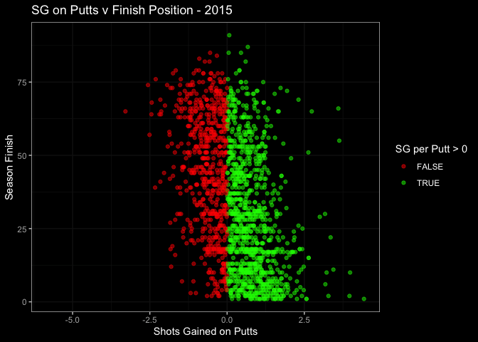

```r
# Animate plot
animate(g_1, nframes = 8, duration = 4)
```

```r
anim_save("sg-putts-v-finish.gif")
```

```r
a <- na.omit(pga_df_rank[c("sg_putt", "Finish_numeric")])

# Calculate the correlation between 'strokes' and 'sg_putt'
correlation <- cor(a$sg_putt, a$Finish_numeric)

# Print the correlation coefficient
print(correlation)
```

```
## [1] -0.4346321
```

We wanted to look at how important shots gained while putting would be toward overall finish position at a given tournament. It is worth noting that there are still many entries in the data set of players who did not make the cut at a tournament and thus cannot be represented on a numeric y axis of overall finish. We can see that across all years the players closest to the bottom of the graph, being closest to 1st place, putt overwhelmingly better than the majority of the field, with very positive shots gained while putting. This would indicate that putting does play a crucial role in winning tournaments and consistently finishing in the top of the field, while players that are more average at putting can still make cuts (and therefore make money) and top 100 placements, but are less likely to reach the best players.

## Bryson DeChambeau

```r
dechambeau_df <- pga_df_rank[pga_df_rank$Player_initial_last == 'B. DeChambeau', ]
```

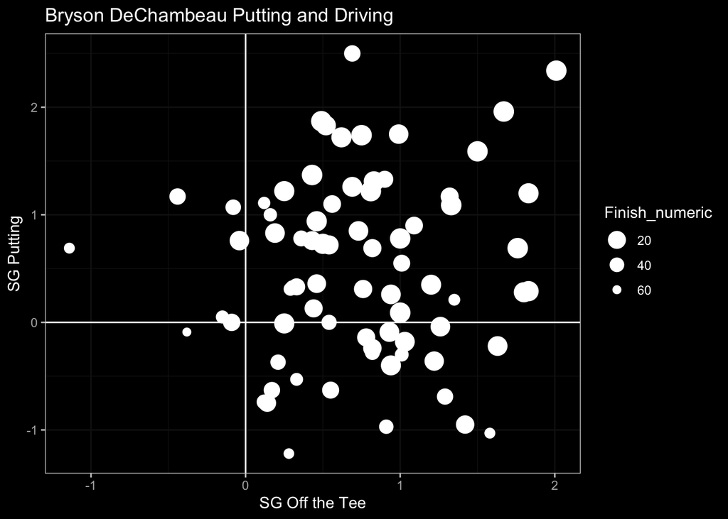

```r
ggplot(data = dechambeau_df, # Set dataset
                 aes(x = sg_ott,
                     y = sg_putt,
                     size = Finish_numeric)) +
  geom_point() + # Set geom point to create scatter plot
  scale_size(trans = 'reverse') + # reverse scale so placing closer to 1st gets a bigger point
  dark_theme_bw() + # Set dark theme
  geom_hline(yintercept = 0) + # Add line for 0 sg_putt
  geom_vline(xintercept = 0) + # Add line for 0 sg_ott
   labs(x = "SG Off the Tee", # Add labels
       y = "SG Putting",
       title = "Bryson DeChambeau Putting and Driving")
```

Bryson DeChambeau is known for his power off the tee which he has used to cut off large sections of holes and reach holes that other players have to lay up for. We can see here that his best performances, indicated by larger dots, are usually when he is gaining shots on the field with his tee shots. His putting also seems to help although he has far more tournaments with negative shots gained putting compared to shots gained off the tee. Also, the small dots seem to be more concentrated on the overall left side of the graph as opposed to the bottom left or bottom of the distribution, indicating that putting has less of an effect for Bryson on overall placement. Thus, we can conclude that when Bryson can use his power off the tee effectively (i.e. by staying in the fairway while outdriving his opponents), he is more likely to finish higher in the tournament and win more money.

## Shots Gained by Shot Type and Season

```r
# Select just season, sg_ott and sg_putt
pga_df_3 <- pga_df[, c('season', 'sg_ott', 'sg_putt')]

# melt the data into long form
pga_df_melt <- melt(pga_df_3, id = 'season')
```

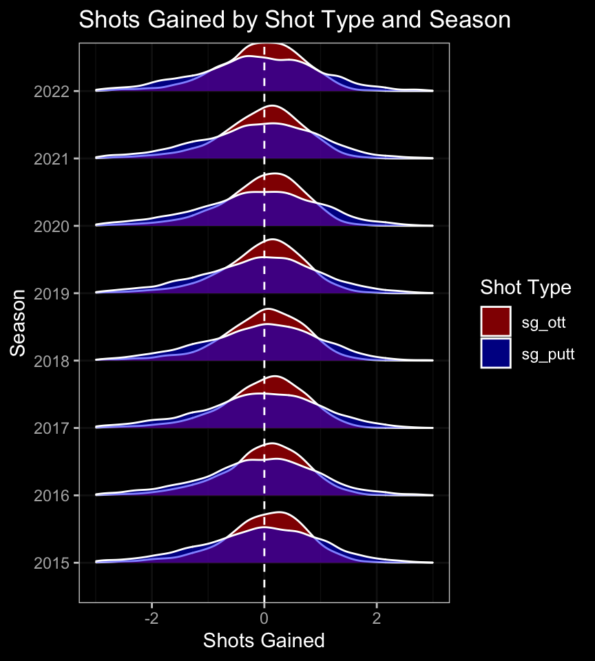

```r
# Create plot
ggplot(pga_df_melt, # Set dataset
       aes(x = value, y = factor(season), fill = factor(variable))) + # Set aesthetics
  geom_density_ridges(alpha = 0.5, scale = 0.8) + # Set density to create distribution
  scale_x_continuous(limits = c(-3, 3)) +
  theme_minimal() + # Set plot theme
  labs(x = "Shots Gained", title = "Shots Gained by Shot Type and Season", # Set plot labels
       fill = "Shot Type", y = "Season") +
  scale_fill_manual(values = c("sg_ott" = "red", "sg_putt" = "blue")) + # Set colors manually
  dark_theme_bw() + # Set theme
  geom_vline(xintercept = 0, linetype = 2, color = "white") # Add vertical line at 0
```

We wanted to look at whether there has been a shift over the last few seasons in focusing more on improvements in shots off the tee or putting. With the discussions over recent months concerning regulations for golf balls in an attempt to curb players from continuing to improve their long shot yardages, it may actually be too early for this analysis. The aim of these efforts is to prevent courses from having to continually lengthen their courses so that pros cannot just drive the greens and rely on a few clubs rather than have to play holes the way they were designed to be played. Thus, we were expecting to see a trend toward shots gained off the tee since the best of the best have been making steady improvements in their tee yardages for the last few years. However, there is no significant trend to be seen in this graph. What is notable from this graph is that shots gained from putting consistently has a more spread out distribution than shots off the tee, indicating that putting is where a lot of players can make or break their rounds. This tells us that most players won’t gain any significant advantage off the tee, but they can certainly leap ahead or fall behind on the greens.

## Plot 4

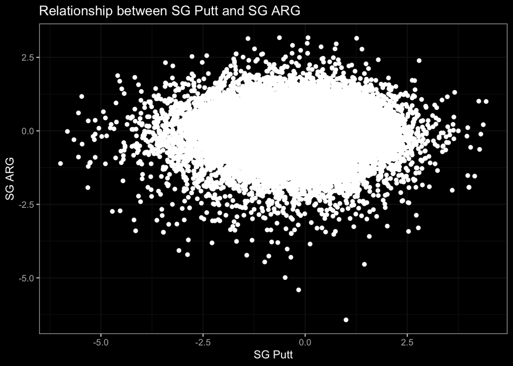

```r
ggplot(pga_df, aes(x = sg_putt, y = sg_arg)) +
  geom_point() +
  dark_theme_bw() +
  labs(x = "SG Putt", y = "SG ARG") +
  ggtitle("Relationship between SG Putt and SG ARG")
```

```r
cleaned_data <- na.omit(pga_df[c("sg_arg", "sg_putt")])

# Calculate the correlation between 'strokes' and 'sg_putt'
correlation <- cor(cleaned_data$sg_arg, cleaned_data$sg_putt)

# Print the correlation coefficient
print(correlation)
```

```
## [1] 0.03167309
```

## Plot 5

Now we will visualize the relationship between the number of pars a player has while on tour (hole_par) and their strokes gained off the tee (sg_ott). I would expect that the more pars a player has, the higher their strokes gained off the tee is. This means there would be a positive correlation between the two.

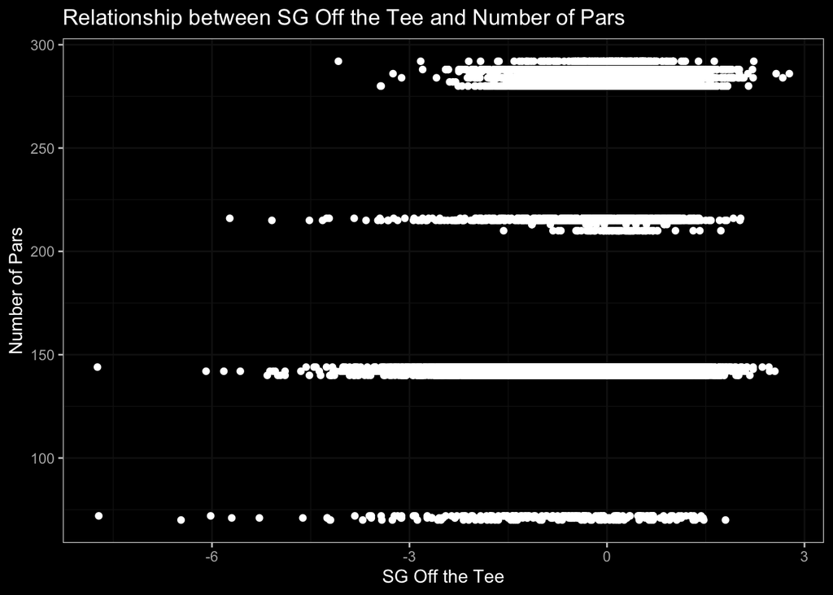

```r
ggplot(pga_df, aes(x = sg_ott, y = hole_par)) +
  geom_point() +
  dark_theme_bw() +
  labs(x = "SG Off the Tee", y = "Number of Pars") +
  ggtitle("Relationship between SG Off the Tee and Number of Pars")
```

Firstly, I did not expect the data to be grouped as it is above. Here we see that as the number of pars for a player increases, a player’s SG Off the Tee generally goes up. This brings new meaning to the data for me. Although I did not realize it before, it seems that the best players play more rounds in the tour than the worse players due to the cut off. This clicked with me because there are four rounds in the tour, which is why the number of pars is in four groups, and, as the rounds go on, the players who remain have higher SG Off the Tee (because the player pool that remains at the end is better than the one in the beginning).

## Plot 6

Now knowing this, I modified the above graph to include whether or not a player made the cut by color, red being the player did not make the cut and green being the player made the cut. We should expect that after a certain number of rounds, all players will be green.

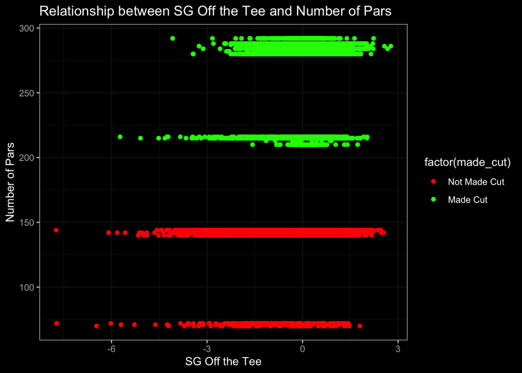

```r
# Create a scatter plot for 'strokes' vs 'sg_putt' with points colored based on 'made_cut'
ggplot(pga_df, aes(x = sg_ott, y = hole_par, color = factor(made_cut))) +
  geom_point() +
  dark_theme_bw() +
  labs(x = "SG Off the Tee", y = "Number of Pars") +
  ggtitle("Relationship between SG Off the Tee and Number of Pars") +
  scale_color_manual(values = c("red", "green"), labels = c("Not Made Cut", "Made Cut"))
```

This graph really clears things up. We can see that a player makes the cut for the tour if they make it past the second round.

## Plot 7

To completely confirm that the best players make it to the later rounds and the worse players do not, I next want to see the relationship between the total strokes gained for a player and the number of rounds they competed in. Now that I know there are four distinct groups of players, I will use a box and whisker plot to visualize this relationship.

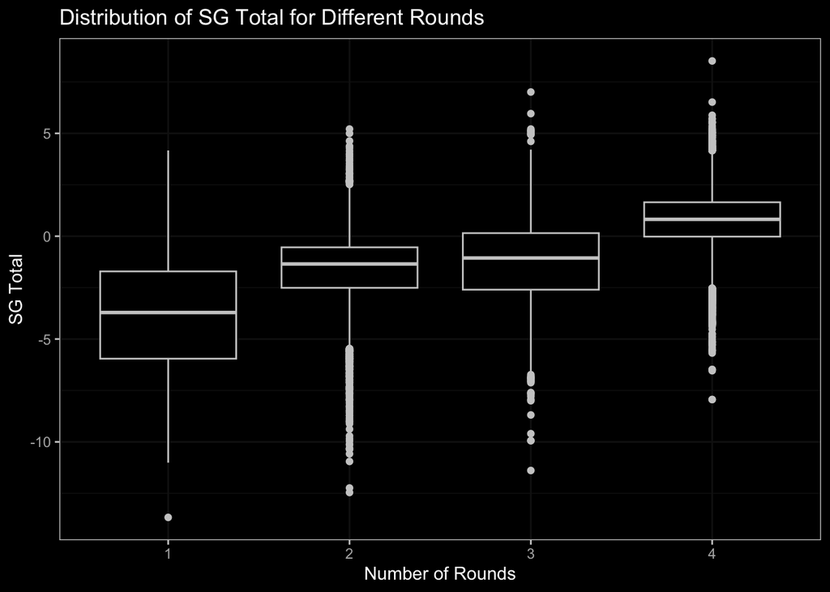

```r
ggplot(pga_df, aes(x = factor(n_rounds), y = sg_total)) +
  geom_boxplot() +
  dark_theme_bw() +
  labs(x = "Number of Rounds", y = "SG Total") +
  ggtitle("Distribution of SG Total for Different Rounds")
```

Beautiful! In this data, we can see that as the number of rounds a player competes in goes up, their total strokes gained increases. Again, this stands to reason because in the later rounds, the worse players have been cut and only the best remain. As we became more familiar with the data, we were able to create better and better visualizations from which to draw insights from.

## Age Analysis

Let’s create some age groups

```r
valid_age <- pga_df_rank[!is.na(pga_df_rank$true_age),]

valid_age$age_group <- rep(NA, length(valid_age$true_age))

for (i in 1:length(valid_age$true_age)) {
  if (valid_age$true_age[i] > 50) {
    valid_age$age_group[i] <- '50+'
  } else if (valid_age$true_age[i] > 40) {
    valid_age$age_group[i] <- '41-50'
  } else if (valid_age$true_age[i] > 30) {
    valid_age$age_group[i] <- '31-40'
  } else if (valid_age$true_age[i] > 20) {
    valid_age$age_group[i] <- '21-30'
  } else if (valid_age$true_age[i] < 21) {
    valid_age$age_group[i] <- '< 21'
  }
}
```

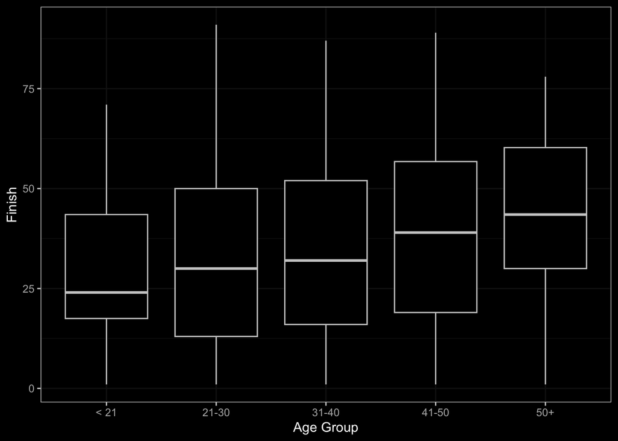

```r
ggplot(data = valid_age,
       mapping = aes(x=age_group,
                     y=Finish_numeric)) +
  geom_boxplot() +
  xlab('Age Group') +
  ylab('Finish') +
  dark_theme_bw() # Set dark theme
```

Let’s look at Bryson’s development as a player

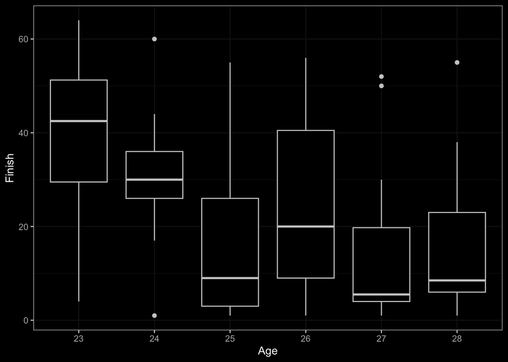

```r
ggplot(data = dechambeau_df[!is.na(dechambeau_df$true_age), ],
       mapping = aes(x=as.factor(true_age),
                     y=Finish_numeric)) +
  geom_boxplot() +
  xlab('Age') +
  ylab('Finish') +
  dark_theme_bw() # Set dark theme
```

Let’s see how the average age of players in the PGA has changed over the years

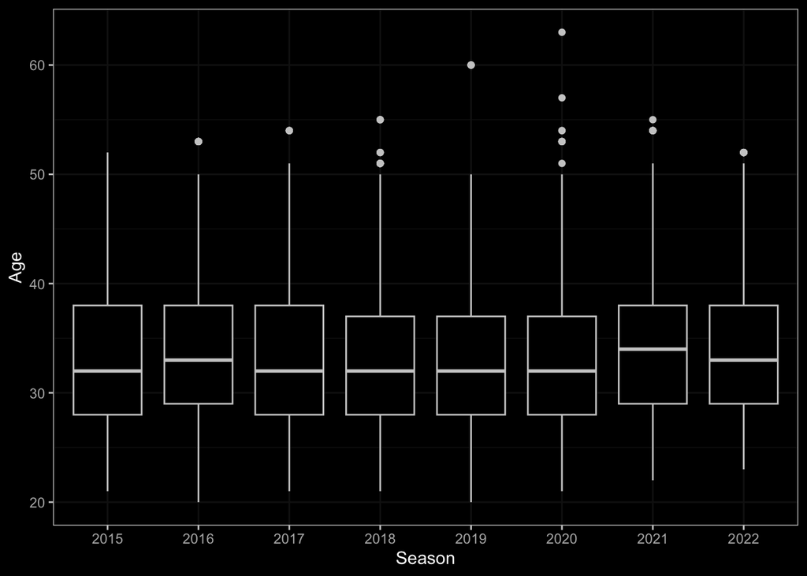

```r
ggplot(data = valid_age,
       mapping = aes(x=as.factor(season),
                     y=true_age)) +
  geom_boxplot() +
  xlab('Season') +
  ylab('Age') +
  dark_theme_bw() # Set dark theme
```

Now, let’s see how different shot type metrics compare across age groups.

```r
season_age_grouped <- valid_age %>%
  dplyr::group_by(season, age_group) %>%
  summarise(Count = length(Player_initial_last),
            Avg_sg_putt = mean(sg_putt),
            Avg_sg_arg = mean(sg_arg),
            Avg_sg_app = mean(sg_app),
            Avg_sg_ott = mean(sg_ott),
            Avg_sg_t2g = mean(sg_t2g),
            Avg_sg_total = mean(sg_total))
season_age_grouped[order(season_age_grouped$Count), c('season', 'age_group', 'Count')]
```

```
## # A tibble: 34 × 3
## # Groups:   season [8]
##    season age_group Count
##     <dbl> <chr>     <int>
##  1   2016 < 21          1
##  2   2019 50+           4
##  3   2017 50+           5
##  4   2019 < 21          7
##  5   2020 50+          10
##  6   2016 50+          11
##  7   2015 50+          13
##  8   2018 50+          13
##  9   2022 50+          16
## 10   2021 50+          29
## # ℹ 24 more rows
```

We can see that the under 21 age group only has 8 total data points (1 for the 2016 season and 7 for the 2019), which is far less than the other age groups, so we will remove these data points in our visuals.

### Calculate % Change of SG Metrics by Age Group over the years

Next, let’s calculate the percentage change for each of our shots gained metrics from season to season for each age group.

```r
season_age_grouped <- season_age_grouped %>%
  group_by(season) %>%
  arrange(age_group) %>%
  mutate(across(c('Avg_sg_putt', 'Avg_sg_arg', 'Avg_sg_app', 'Avg_sg_ott', 'Avg_sg_t2g', 'Avg_sg_total'),
                ~ (./lag(.) - 1) * 100,
                .names = "perc_change_{.col}"))
```

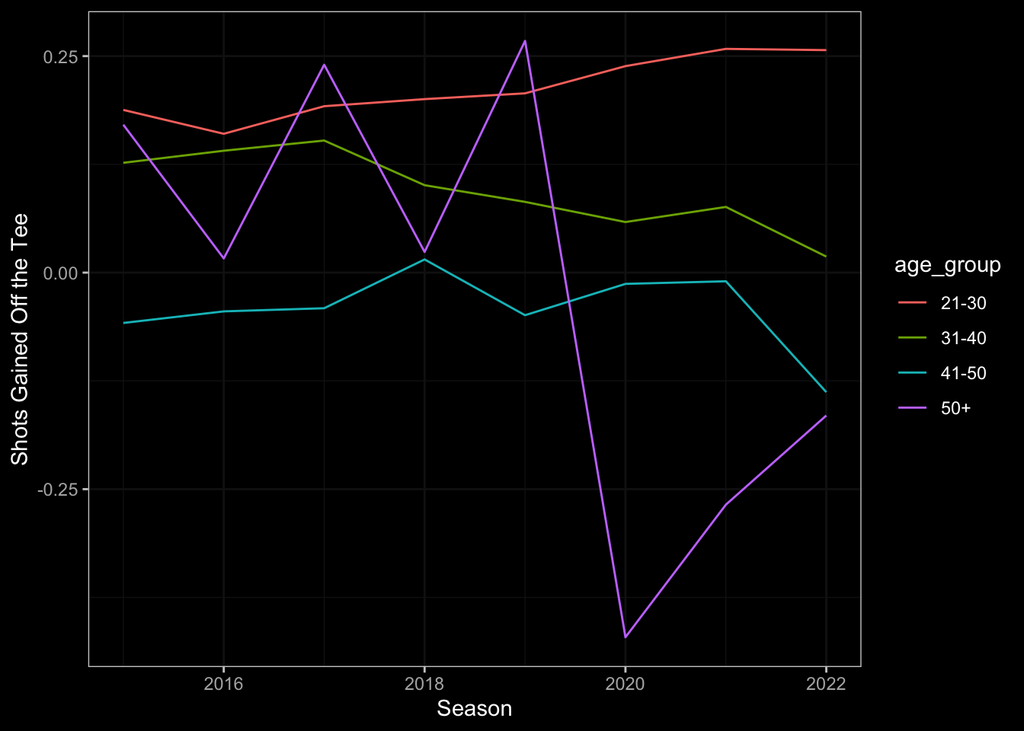

```r
ggplot(data = season_age_grouped[season_age_grouped$age_group != '< 21', ], # remove the under 21 data points
       aes(x = season,
           y = Avg_sg_ott,
           color = age_group)) +
  geom_line() +
  xlab('Season') +
  ylab('Shots Gained Off the Tee') +
  dark_theme_bw() # Set dark theme
```

We can see that over the last few years, the performance gap has widened between age groups off the tee. This is indicative of the trends that we have seen with technological innovations and an influx of younger talent leading to more explosive players with longer yardages to gain an advantage over the rest of the field. Younger players (21-30) have seen an increase in strokes gained from the tee box while all other age groups have seen decreases over the same period of 7 years.

Let’s look at the percentage changes instead

```r
colnames(season_age_grouped)
```

```
##  [1] "season"                   "age_group"
##  [3] "Count"                    "Avg_sg_putt"
##  [5] "Avg_sg_arg"               "Avg_sg_app"
##  [7] "Avg_sg_ott"               "Avg_sg_t2g"
##  [9] "Avg_sg_total"             "perc_change_Avg_sg_putt"
## [11] "perc_change_Avg_sg_arg"   "perc_change_Avg_sg_app"
## [13] "perc_change_Avg_sg_ott"   "perc_change_Avg_sg_t2g"
## [15] "perc_change_Avg_sg_total"
```

```r
season_age_grouped
```

```
## # A tibble: 34 × 15
## # Groups:   season [8]
##    season age_group Count Avg_sg_putt Avg_sg_arg Avg_sg_app Avg_sg_ott
##     <dbl> <chr>     <int>       <dbl>      <dbl>      <dbl>      <dbl>
##  1   2015 21-30       636       0.277     0.127       0.255      0.188
##  2   2016 21-30       670       0.244     0.0925      0.174      0.160
##  3   2017 21-30       890       0.287     0.0762      0.206      0.192
##  4   2018 21-30       798       0.191     0.103       0.285      0.200
##  5   2019 21-30       973       0.228     0.0898      0.185      0.207
##  6   2020 21-30       744       0.303     0.0602      0.246      0.238
##  7   2021 21-30       836       0.207     0.0965      0.317      0.258
##  8   2022 21-30       590       0.290     0.0701      0.370      0.257
##  9   2015 31-40       739       0.232     0.123       0.324      0.127
## 10   2016 31-40       814       0.145     0.0895      0.340      0.141
## # ℹ 24 more rows
## # ℹ 8 more variables: Avg_sg_t2g <dbl>, Avg_sg_total <dbl>,
## #   perc_change_Avg_sg_putt <dbl>, perc_change_Avg_sg_arg <dbl>,
## #   perc_change_Avg_sg_app <dbl>, perc_change_Avg_sg_ott <dbl>,
## #   perc_change_Avg_sg_t2g <dbl>, perc_change_Avg_sg_total <dbl>
```

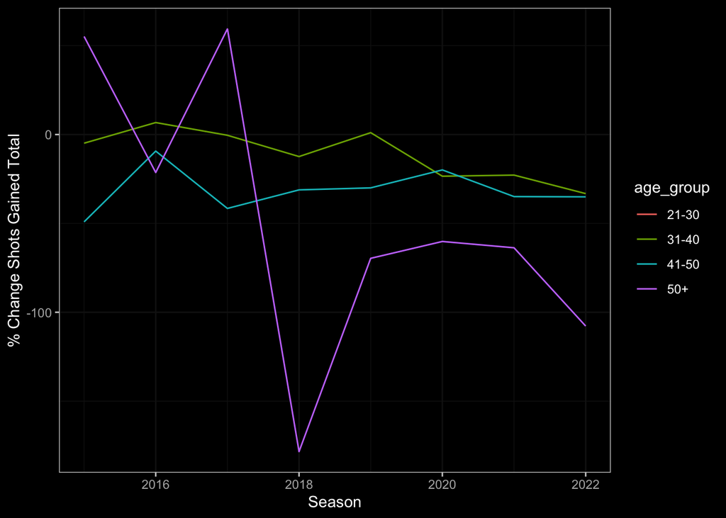

```r
ggplot(data = season_age_grouped[season_age_grouped$age_group != '< 21', ],
       aes(x = season,
           y = perc_change_Avg_sg_total,
           color = age_group)) +
  geom_line() +
  xlab('Season') +
  ylab('% Change Shots Gained Total') +
  dark_theme_bw() # Set dark theme
```

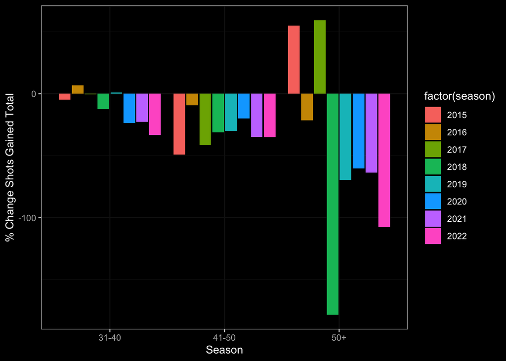

```r
ggplot(data = season_age_grouped[season_age_grouped$age_group != '< 21', ],
       aes(x = age_group,
           y = perc_change_Avg_sg_total,
           fill = factor(season))) +
  geom_bar(stat="identity", position = 'dodge2') +
  scale_x_discrete(limits = c('31-40', '41-50', '50+')) +
  xlab('Season') +
  ylab('% Change Shots Gained Total') +
  dark_theme_bw() # Set dark theme
```

Here we can see that as when we calculate the percentage change from the 21-30 age group through to 50+, the overwhelming trend is that PGA professionals worsen as they age. Nearly all of the changes in average total shots gained on the field are negative, showing that players will typically be in their prime when in the 21-30 age range. Thus, for veteran players like Tiger Woods or Adam Scott, two players in the 41-50 age range, to still be competing at a high level against fields far younger than them is truly an impressive feat.